```r
# 2. Make design matrix.
dat.uni$controlTrial = as.factor(dat.uni$controlTrial)
formula = ~1+stimLLoc*controlTrial + controlTrial*stimRLoc +oneBack
#formula = ~1+stimLLoc*controlTrial*stimRLoc +oneBack

X <- unname(model.matrix(formula, dat.uni))
X_fix = with(dat.uni,cbind(handedness,dominantEye,experiment=='Control',experiment=='Horizontal'))
```

Because the sampling takes approx. 2.7h we load it

```r
# 4. Make Stan data.
stanDat <- within(list(),
                  {
                    N<-nrow(X)
                    P <- n_u <- n_w <- ncol(X)
                    P2 <- ncol(X_fix)
                    X <- Z_u <- Z_w <- X
                    X_fix <- X_fix
                    J <- length(levels(dat.uni$subject))
                    answer <- as.logical(dat.uni$answer)
                    subj <- as.integer(dat.uni$subject)
                  }
)
# 5. Fit the model.
#factorialFit <- stan(file="matrix_model.stan",data=stanDat,iter=2000, chains=6,cores = 6,open_progress = T)



load('../cache/stan/stan_with_between_22_09_2015.RData')
```

## Convergence Diagnostics

### Autocorrelation

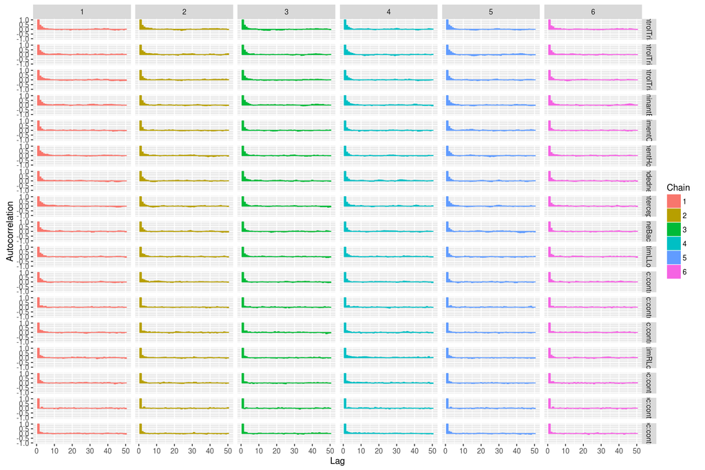

```r
ggs_autocorrelation(S)
```

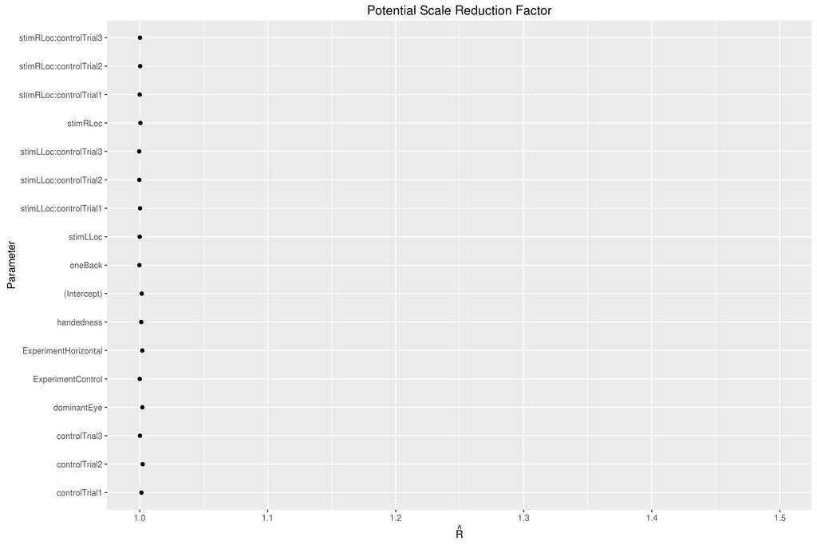

```r
ggs_Rhat(S)
```

All are below 1.1, we have indications that we converged on a useful solution

### Partial Density

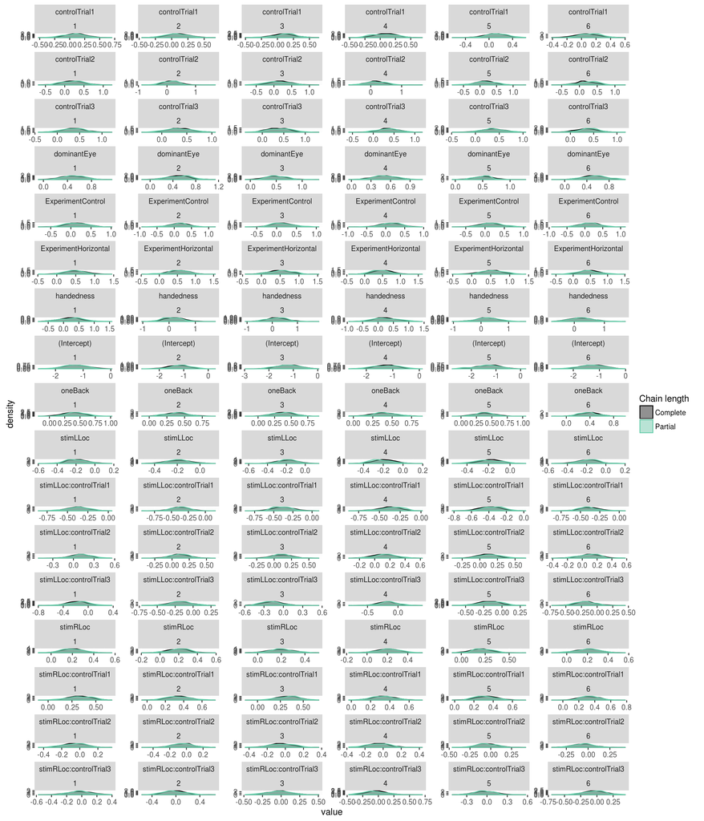

```r
ggs_compare_partial(S)
```

The first 10% seem to be in the same range as the rest of the parameters for all chains, thus burnin/warmup was enough

## Posterior Densities

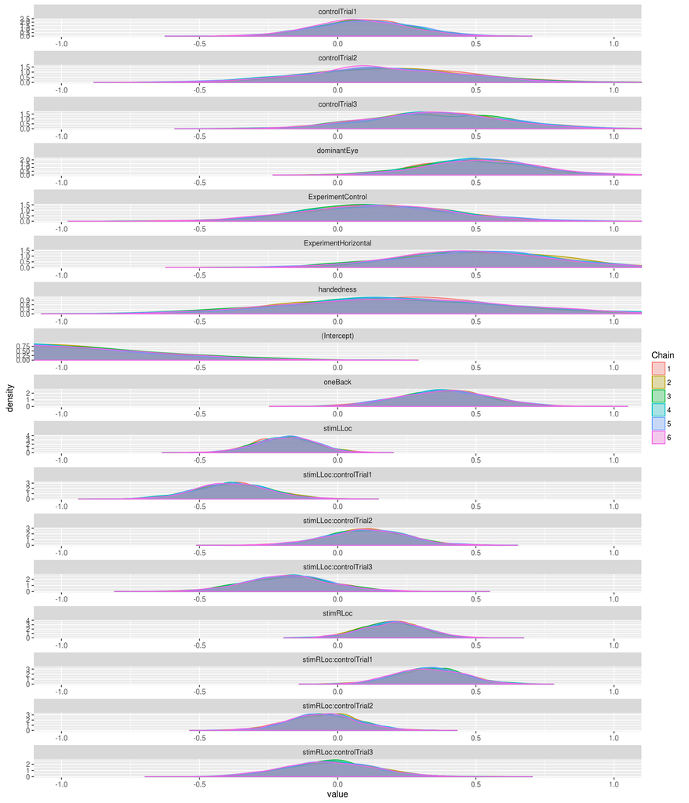

```r
ggs_density(S)+coord_cartesian(xlim=c(-1,1))
```

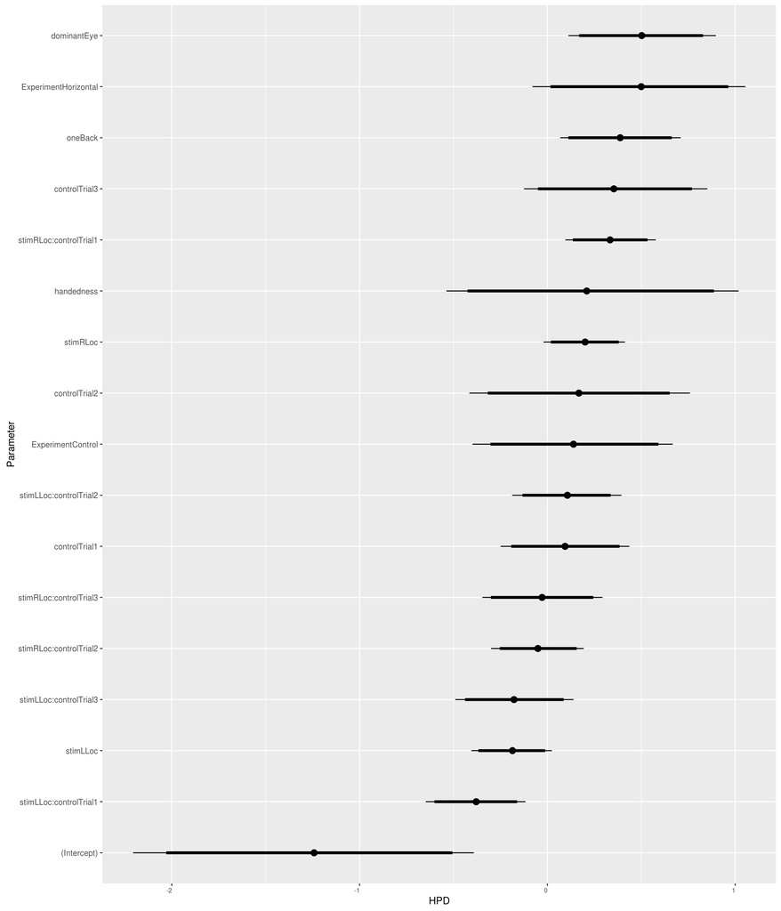

```r
ggs_caterpillar(S)
```

## Contrasts of interest

In general, contrasts can be calculated by subtracting samples of the chains of factors of interest. One has to be careful because this quantity does not have a direct prior, and is susceptible to the borel-Kolmonogrov Paradox.

We fold over the two eyes/temporal fields. I.e. we take (left-right)/2 which takes the mean with one side inverted (the effect goes to the other side here).

To test whether BS is special, we take the differences of the BS effect and the now calculated location effects. We show 95% and 99% HDI

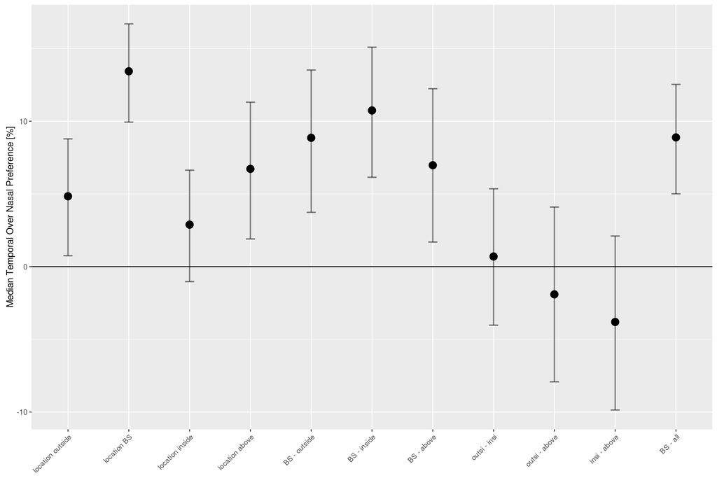

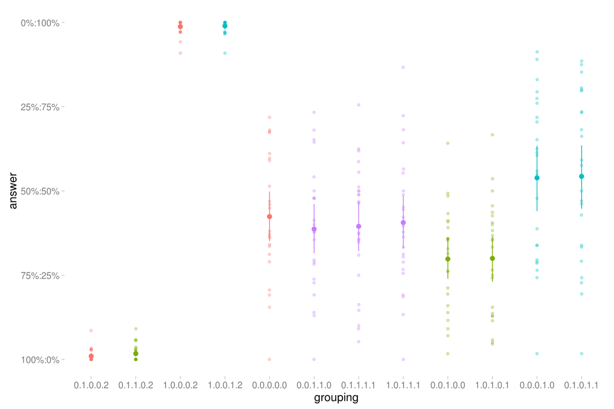

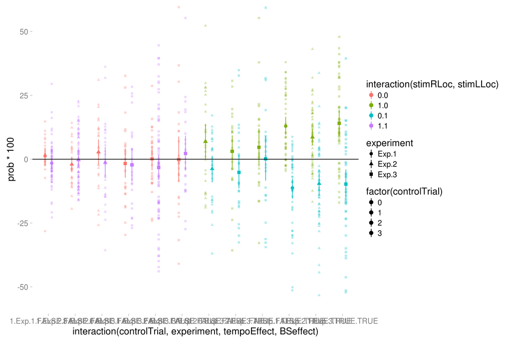

RUN BS_STAN_MATRIX.R BEFORE THIS FILE!

```
## [1] (Intercept) stimLLoc    stimRLoc    oneBack     handedness  dominantEye
## 6 Levels: dominantEye handedness (Intercept) oneBack ... stimRLoc
```

```
## [1] (Intercept)            stimLLoc               controlTrial3
## [4] stimRLoc               oneBack                stimLLoc:controlTrial3
## [7] stimRLoc:controlTrial3 handedness             dominantEye
## 9 Levels: controlTrial3 dominantEye handedness (Intercept) ... stimRLoc:controlTrial3
```

```
##  [1] (Intercept)            stimLLoc               controlTrial1
##  [4] controlTrial2          stimRLoc               oneBack
##  [7] stimLLoc:controlTrial1 stimLLoc:controlTrial2 stimRLoc:controlTrial1
## [10] stimRLoc:controlTrial2 handedness             dominantEye
## 12 Levels: controlTrial1 controlTrial2 dominantEye ... stimRLoc:controlTrial2
```

BS Loc effect only experiment 1: m = 15.01% HDI_95:[8.49%,21.08%])

We found a temporal bias for selecting the temporal stimulus inside (12.5% HDI_95:[7.35%,17.49%]) as well as above the blind spot (6.63% HDI_95=[0.77%,12.3%]). The bias was stronger inside the blind spot (Diff:6.11%, HDI_95=[1.16%,10.78%]).

The blind spot location again revealed the strongest effect (13.18% HDI_95:[6.47%,19.64%]), while the location outwards resulted in a bias of 4.8% (HDI_95=[0.58%,8.89%]), whereas the one inwards, thus closest to the fixation cross, resulted in a non-significant bias of 2.85% (HDI_95=[-1.1%,6.65%]). Both locations show a significant difference in bias to the blind spot location (outward vs. BS: 8.61% (HDI_95=[0.98%,16.04%]), inward vs BS: 10.51% (HDI_95=[3.55%,17.29%]).

```
##   Parameter.experiment Parameter.Parameter median hdi0.01 hdi0.025
## 1                  EEG         location BS  15.01    7.07     8.49
## 2              Control         location BS  12.50    6.30     7.35
## 3              Control      location above   6.63   -0.34     0.77
## 4              Control          BS - above   6.11    0.14     1.16
## 5                Horiz    location outside   4.80   -0.28     0.58
## 6                Horiz         location BS  13.18    5.07     6.47
## 7                Horiz     location inside   2.85   -1.83    -1.10
## 8                Horiz        BS - outside   8.61   -0.54     0.98
## 9                Horiz         BS - inside  10.51    2.09     3.55
##   hdi0.975 hdi0.99
## 1    21.08   22.33
## 2    17.49   18.39
## 3    12.30   13.47
## 4    10.78   11.69
## 5     8.89    9.73
## 6    19.64   20.94
## 7     6.65    7.39
## 8    16.04   17.50
## 9    17.29   18.63
```

| Parameter | Experiment 1 (95% CI) | Experiment 2 (95% CI) | Experiment 3 (95% CI) |
| --- | --- | --- | --- |
| location BS | 15.01% [8.49%,21.08%] |  |  |
| location BS |  | 12.50% [7.35%,17.49%] |  |
| location above |  | 6.63% [0.77%,12.30%] |  |
| BS - above |  | 6.11% [1.16%,10.78%] |  |
| location outside |  |  | 4.80% [0.58%,8.89%] |
| location BS |  |  | 13.18% [6.47%,19.64%] |
| location inside |  |  | 2.85% [-1.10%,6.65%] |
| BS - outside |  |  | 8.61% [0.98%,16.04%] |
| BS - inside |  |  | 10.51% [3.55%,17.29%] |

| parameter | All.experiments..95..CI. |
| --- | --- |
| location outside | 4.84% [0.75%,8.79%] |
| location BS | 13.44% [9.94%,16.70%] |
| location inside | 2.89% [-1.03%,6.63%] |
| location above | 6.73% [1.91%,11.31%] |
| BS - outside | 8.86% [3.73%,13.52%] |
| BS - inside | 10.74% [6.15%,15.09%] |
| BS - above | 6.97% [1.69%,12.24%] |
| outsi - insi | 0.70% [-4.02%,5.35%] |
| outsi - above | -1.91% [-7.92%,4.10%] |
| insi - above | -3.80% [-9.86%,2.11%] |
| BS - all | 8.89% [5.01%,12.53%] |

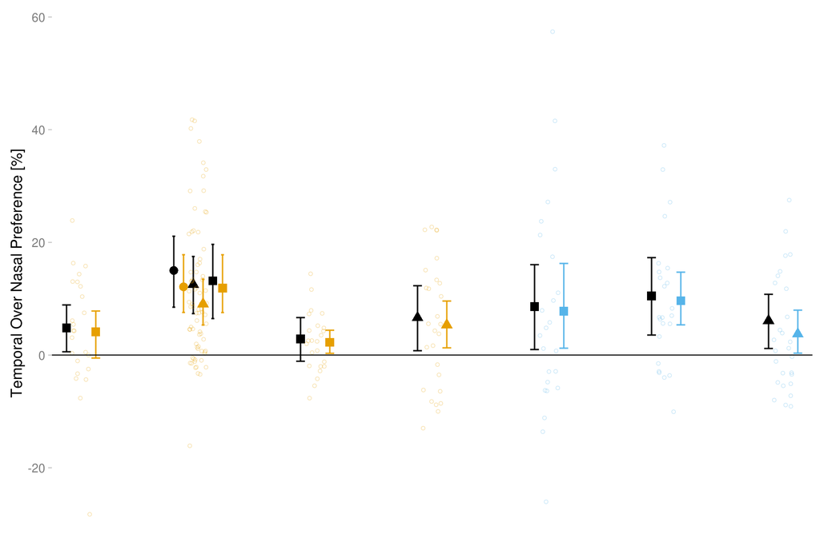

```
##    mean se_mean      sd    2.5%     25%     50%     75%   97.5%   n_eff
##    1.38    0.00    0.12    1.17    1.29    1.38    1.46    1.64 2469.22
##    Rhat
##    1.00
```

```
## controlTrial1: median = 2.35% (hdi_95=[-6.19%, 10.74%]
## controlTrial2: median = 4.18% (hdi_95=[-10.24%, 18.12%]
## controlTrial3: median = 8.76% (hdi_95=[-3.11%, 20.09%]
## dominantEye: median = 12.30% (hdi_95=[2.78%, 21.04%]
## ExperimentControl: median = 3.47% (hdi_95=[-9.84%, 16.09%]
## ExperimentHorizontal: median = 12.24% (hdi_95=[-1.98%, 24.16%]
## handedness: median = 5.22% (hdi_95=[-13.12%, 23.46%]
## (Intercept): median = -27.60% (hdi_95=[-40.08%, -9.66%]
## oneBack: median = 9.57% (hdi_95=[1.70%, 17.03%]
## stimLLoc: median = -4.64% (hdi_95=[-9.98%, 0.59%]
## stimLLoc:controlTrial1: median = -9.37% (hdi_95=[-15.64%, -2.91%]
## stimLLoc:controlTrial2: median = 2.66% (hdi_95=[-4.67%, 9.72%]
## stimLLoc:controlTrial3: median = -4.44% (hdi_95=[-12.02%, 3.47%]
## stimRLoc: median = 5.01% (hdi_95=[-0.51%, 10.18%]
## stimRLoc:controlTrial1: median = 8.26% (hdi_95=[2.39%, 14.04%]
## stimRLoc:controlTrial2: median = -1.26% (hdi_95=[-7.44%, 4.82%]
## stimRLoc:controlTrial3: median = -0.71% (hdi_95=[-8.56%, 7.30%]
```